# USFS FIA Tree Data Review

Jennifer Truong

9/13/2020

# Preliminary Data Analysis

### Observing Unique Species

YPMC Conifer species we are focusing on for our GP:

| Scientific Name | Common Name | Code |
| --- | --- | --- |
| Pinus ponderosa | Ponderosa pine | PIPO |
| Pinus jeffreyi | Jeffery pine | PIJE |
| Pinus lambertiana | Sugar pine | PILA |
| Abies concolor | White fir | ABCO |
| Calocedrus decurrens | Incense cedar | CADE |

Affiliate species that we may look at:

| Scientific Name | Common Name | Code |
| --- | --- | --- |
| Pinus coulteri | Coulter pine | PIC3 |
| Pseudotsuga macrocarpa | Big cone douglas fir | PSMA |
| Quercus kelloggii | California black oak | QUKE |
| Quercus chrysolepis | Canyon live oak | QUCH |

Conifer species we are not considering for our analysis:

| Scientific Name | Common Name | Code |
| --- | --- | --- |
| Pinus contorta ssp. murrayana | Lodgepole pine | PICOM |

### Setup for Filtering Plots by Species

### Tree Size Classes

Diameter base height in cm; classes determined from Figure 19 (pg 106 hard-copy and 116 digital) in Safford and Stevens 2017

Use variable DBHI and convert from inches to cm

- 5 - 20 cm
- 20 - 40 cm
- 40 - 60 cm
- 60 - 80 cm
- 80 - 100 cm
- 100 - 120 cm
- 120 - 140 cm
- /> 140 cm

# FIA Data Analysis by NF

### Data Collection Dates

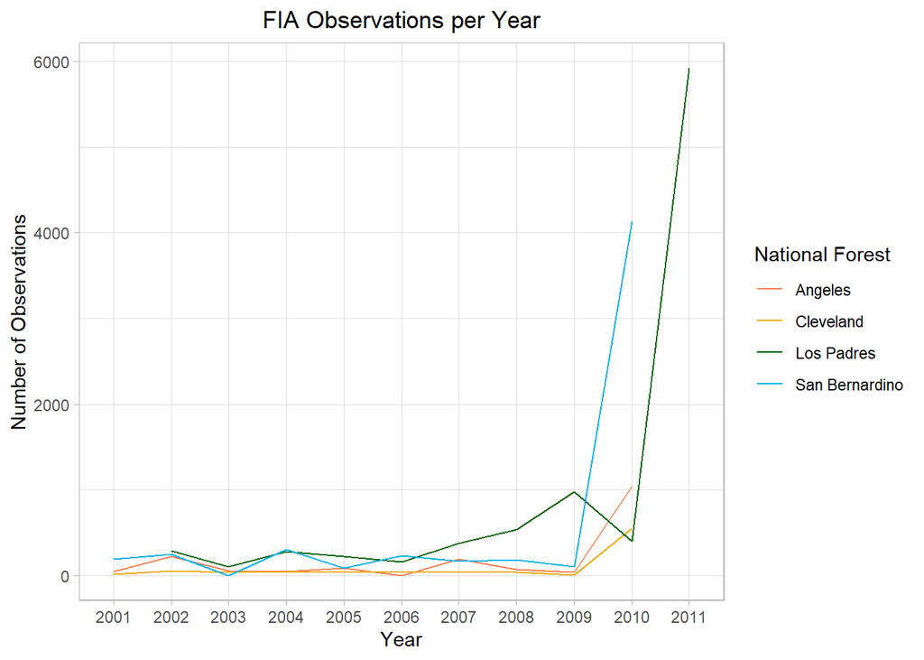

Los Padres seems to have the most observations overall. The highest amount of observations occurred in 2011 with 6000 observations total. This wsas followed by San Bernardino with about 4000 observations in 2010.

### Number of FIA Observations

| forest | n |
| --- | --- |
| Angeles | 1812 |
| Cleveland | 843 |
| NA | 9285 |
| NA | 5662 |

### YPMC Conifer Count

| forest | species | n |
| --- | --- | --- |
| 01 | ABCO | 108 |
| 01 | CADE | 21 |
| 01 | PICO | 10 |
| 01 | PICOM | 24 |
| 01 | PIJE | 152 |
| 01 | PILA | 59 |
| 01 | PIPO | 2 |
| 01 | PSMA | 90 |
| 01 | QUCH | 607 |
| 01 | QUKE | 1 |
| 02 | ABCO | 1 |
| 02 | CADE | 6 |
| 02 | PICO | 13 |
| 02 | PIJE | 41 |
| 02 | PSMA | 19 |
| 02 | QUCH | 220 |
| 02 | QUKE | 53 |
| 07 | ABCO | 135 |
| 07 | CADE | 32 |
| 07 | PICO | 80 |
| 07 | PIJE | 548 |
| 07 | PILA | 73 |
| 07 | PIPO | 23 |
| 07 | PSMA | 243 |
| 07 | QUCH | 2523 |
| 07 | QUKE | 84 |
| 12 | ABCO | 910 |
| 12 | CADE | 171 |
| 12 | PICO | 137 |
| 12 | PICOM | 207 |
| 12 | PIJE | 579 |
| 12 | PILA | 187 |
| 12 | PIPO | 59 |
| 12 | PSMA | 62 |
| 12 | QUCH | 1531 |
| 12 | QUKE | 331 |

### Number of Trees per Plot

There are 1022 plots in all four Southern California national forests.

| gis_link | species | species_n | total_n | pct |
| --- | --- | --- | --- | --- |
| ANFPLUS10_101001 | ABCO | 17 | 51 | 33.33 |
| ANFPLUS10_101001 | PIJE | 1 | 51 | 1.96 |
| ANFPLUS10_101001 | PILA | 33 | 51 | 64.71 |
| ANFPLUS10_101010 | QUCH | 7 | 7 | 100.00 |
| ANFPLUS10_101013 | PSMA | 2 | 7 | 28.57 |
| ANFPLUS10_101013 | QUCH | 5 | 7 | 71.43 |
| ANFPLUS10_101014 | QUCH | 10 | 10 | 100.00 |
| ANFPLUS10_101017 | PSMA | 10 | 17 | 58.82 |
| ANFPLUS10_101017 | QUCH | 7 | 17 | 41.18 |
| ANFPLUS10_101018 | ABCO | 1 | 8 | 12.50 |
| ANFPLUS10_101018 | CADE | 2 | 8 | 25.00 |
| ANFPLUS10_101018 | PIJE | 5 | 8 | 62.50 |
| ANFPLUS10_101019 | QUCH | 25 | 25 | 100.00 |
| ANFPLUS10_101020 | CADE | 1 | 2 | 50.00 |
| ANFPLUS10_101020 | QUCH | 1 | 2 | 50.00 |
| ANFPLUS10_101024 | QUCH | 15 | 15 | 100.00 |
| ANFPLUS10_101030 | PICO | 1 | 44 | 2.27 |
| ANFPLUS10_101030 | PSMA | 10 | 44 | 22.73 |
| ANFPLUS10_101030 | QUCH | 33 | 44 | 75.00 |
| ANFPLUS10_101033 | PIJE | 7 | 8 | 87.50 |
| ANFPLUS10_101033 | PILA | 1 | 8 | 12.50 |
| ANFPLUS10_101034 | ABCO | 1 | 62 | 1.61 |
| ANFPLUS10_101034 | PIJE | 12 | 62 | 19.35 |
| ANFPLUS10_101034 | PILA | 3 | 62 | 4.84 |
| ANFPLUS10_101034 | QUCH | 46 | 62 | 74.19 |
| ANFPLUS10_101040 | PICO | 1 | 1 | 100.00 |
| ANFPLUS10_101041 | PIJE | 2 | 19 | 10.53 |
| ANFPLUS10_101041 | QUCH | 17 | 19 | 89.47 |
| ANFPLUS10_101043 | QUCH | 3 | 3 | 100.00 |
| ANFPLUS10_101044 | PSMA | 3 | 8 | 37.50 |

[output cut: 919 more lines]

| gis_link | species | species_n | total_n | pct |
| --- | --- | --- | --- | --- |
| LPFPLUS11_107251 | CADE | 1 | 17 | 5.88 |
| LPFPLUS11_107251 | QUCH | 16 | 17 | 94.12 |
| LPFPLUS11_107303 | CADE | 8 | 35 | 22.86 |
| LPFPLUS11_107303 | PIJE | 8 | 35 | 22.86 |
| LPFPLUS11_107303 | PILA | 8 | 35 | 22.86 |
| LPFPLUS11_107303 | QUCH | 11 | 35 | 31.43 |
| LPFPLUS11_107402 | CADE | 3 | 25 | 12.00 |
| LPFPLUS11_107402 | QUCH | 22 | 25 | 88.00 |
| LPFPLUS11_107433 | ABCO | 4 | 22 | 18.18 |
| LPFPLUS11_107433 | CADE | 2 | 22 | 9.09 |
| LPFPLUS11_107433 | PILA | 7 | 22 | 31.82 |
| LPFPLUS11_107433 | PIPO | 3 | 22 | 13.64 |
| LPFPLUS11_107433 | PSMA | 3 | 22 | 13.64 |
| LPFPLUS11_107433 | QUCH | 3 | 22 | 13.64 |
| LPFPLUS11_107721 | CADE | 7 | 31 | 22.58 |
| LPFPLUS11_107721 | PIJE | 9 | 31 | 29.03 |
| LPFPLUS11_107721 | PILA | 7 | 31 | 22.58 |
| LPFPLUS11_107721 | QUCH | 5 | 31 | 16.13 |
| LPFPLUS11_107721 | QUKE | 3 | 31 | 9.68 |
| LPFPLUS11_107722 | CADE | 3 | 31 | 9.68 |
| LPFPLUS11_107722 | PIJE | 3 | 31 | 9.68 |
| LPFPLUS11_107722 | PILA | 5 | 31 | 16.13 |
| LPFPLUS11_107722 | PSMA | 2 | 31 | 6.45 |
| LPFPLUS11_107722 | QUCH | 18 | 31 | 58.06 |
| LPFPLUS11_107732 | CADE | 6 | 39 | 15.38 |
| LPFPLUS11_107732 | PIJE | 7 | 39 | 17.95 |
| LPFPLUS11_107732 | PILA | 1 | 39 | 2.56 |
| LPFPLUS11_107732 | QUCH | 25 | 39 | 64.10 |
| LPFPLUS11_107749 | CADE | 2 | 60 | 3.33 |
| LPFPLUS11_107749 | QUCH | 58 | 60 | 96.67 |

#### Notes about Plots

##### Angeles

1. Plot 01020 has 1 CADE and 1 QUCH according to the table. Matches what’s in the final DF too <- Should I remove it?
2. Plot 01024 has 15 QUCH according to the table. However, in the final DF, more rows are present and they seem to be all YPMC species. I wonder what happened. **Edit:** Grouping by “gis_link” seems to get rid of the disrepancy. Plot 01024 has been removed from the final DF.

### Tree Size Class for all NFs

| Forest | Size Class (cm) | Count |
| --- | --- | --- |
| 01 | 0-5 | 9 |
| 01 | 5-20 | 26 |
| 01 | 20-40 | 54 |
| 01 | 40-60 | 44 |
| 01 | 60-80 | 111 |
| 01 | 80-100 | 68 |
| 01 | 100-120 | 24 |
| 01 | 120-140 | 4 |
| 01 | >140 | 2 |
| 02 | 0-5 | 1 |
| 02 | 5-20 | 2 |
| 02 | 20-40 | 18 |
| 02 | 40-60 | 10 |
| 02 | 60-80 | 13 |
| 02 | 80-100 | 4 |
| 07 | 0-5 | 21 |
| 07 | 5-20 | 90 |
| 07 | 20-40 | 200 |
| 07 | 40-60 | 116 |
| 07 | 60-80 | 210 |
| 07 | 80-100 | 118 |
| 07 | 100-120 | 43 |
| 07 | 120-140 | 10 |
| 07 | >140 | 3 |
| 12 | 0-5 | 72 |
| 12 | 5-20 | 289 |
| 12 | 20-40 | 464 |
| 12 | 40-60 | 244 |
| 12 | 60-80 | 472 |
| 12 | 80-100 | 249 |
| 12 | 100-120 | 81 |
| 12 | 120-140 | 28 |
| 12 | >140 | 6 |
| 12 | NA | 1 |

| Forest | Size Class (cm) | Species | Count |
| --- | --- | --- | --- |
| 01 | 0-5 | ABCO | 3 |
| 01 | 0-5 | PIJE | 4 |
| 01 | 0-5 | PILA | 2 |
| 01 | 5-20 | ABCO | 10 |
| 01 | 5-20 | CADE | 3 |
| 01 | 5-20 | PIJE | 12 |
| 01 | 5-20 | PILA | 1 |
| 01 | 20-40 | ABCO | 18 |
| 01 | 20-40 | CADE | 3 |
| 01 | 20-40 | PIJE | 26 |
| 01 | 20-40 | PILA | 6 |
| 01 | 20-40 | PIPO | 1 |
| 01 | 40-60 | ABCO | 21 |
| 01 | 40-60 | PIJE | 20 |
| 01 | 40-60 | PILA | 3 |
| 01 | 60-80 | ABCO | 36 |
| 01 | 60-80 | CADE | 8 |
| 01 | 60-80 | PIJE | 50 |
| 01 | 60-80 | PILA | 17 |
| 01 | 80-100 | ABCO | 13 |
| 01 | 80-100 | CADE | 2 |
| 01 | 80-100 | PIJE | 31 |
| 01 | 80-100 | PILA | 21 |
| 01 | 80-100 | PIPO | 1 |
| 01 | 100-120 | ABCO | 5 |
| 01 | 100-120 | CADE | 3 |
| 01 | 100-120 | PIJE | 8 |
| 01 | 100-120 | PILA | 8 |
| 01 | 120-140 | ABCO | 1 |
| 01 | 120-140 | CADE | 1 |

[output cut: 98 more lines]

### Finalizing of FIA Data with YPMC Data

#### Plots in final DF:

| forest | plot | n |
| --- | --- | --- |
| 01 | 001 | 51 |
| 01 | 018 | 8 |
| 01 | 020 | 2 |
| 01 | 033 | 8 |
| 01 | 034 | 62 |
| 01 | 041 | 19 |
| 01 | 052 | 8 |
| 01 | 105 | 32 |
| 01 | 106 | 28 |
| 01 | 114 | 3 |
| 01 | 119 | 14 |
| 01 | 121 | 21 |
| 01 | 124 | 12 |
| 01 | 125 | 27 |
| 01 | 126 | 39 |
| 01 | 128 | 5 |
| 01 | 131 | 21 |
| 01 | 152 | 27 |
| 01 | 153 | 53 |
| 01 | 154 | 53 |
| 01 | 158 | 18 |
| 01 | 173 | 20 |
| 01 | 183 | 12 |
| 01 | 192 | 33 |
| 01 | 196 | 19 |
| 01 | 197 | 28 |
| 02 | 073 | 9 |
| 02 | 085 | 21 |
| 02 | 086 | 17 |
| 02 | 090 | 14 |

[output cut: 178 more lines]

#### Plots removed from final DF:

Notes: the notes below are for when I manually looked through the data frames. I didn’t finish because it took forever.

- **Angeles:** 01010, 01013, 01014, 01017, 01019, 01024, 01030, 01040, 01043, 01044, 01076, 01077, 01081, 01101, 01104, 01110, 01115, 01116, 01118
- Cleveland:
- Los Padres:
- San Bernardino: